# 多项式回归

本讲是关于多项式回归，多项式回归作为线性回归的一个重要组成部分，有着简单快捷，可解释性强的优点，但同样也存在需要先验知识，也就是需要设置变量的指数，也存在过拟合的问题。

需要注意的是，虽然多项式回归是线性回归，但它拟合的数据是非线性的。

我们这次就使用多项式回归去拟合一些非线性的数据。

$\begin{equation} Y=\beta _{0}+\beta _{1}X +\beta_{2}X^{2}+\ldots+\beta_{h}X^{h} \end{equation}$

上面就是多项式回归的形式，我们需要人为决定h是多少，也就是说最高次项是多少

```python
import matplotlib.pyplot as plt
import numpy as np
import pandas as pd
from sklearn.preprocessing import PolynomialFeatures
from sklearn.linear_model import LinearRegression
```

对于多项式回归，我们使用的是sklearn.preprocessing工具包中的PolynomialFeatures函数与sklearn.linear_model工具包下的LinearRegression函数。

就像我上面说的，虽然多项式回归可以拟合非线性的数据，但它本质上是特殊的线性回归，所以使用的是LinearRegression。

```python
GDP=[1008782.5,983751.2,915243.5,830945.7,742694.1,685571.2,644380.2,588141.2,537329,483392.8,410354.1,347934.9,321229.5,270704,219028.5,185998.9,161415.4,136576.3,120480.4,109276.2]
x_year=np.linspace(2021,2001,20)
x_df=pd.DataFrame(x_year)
x=x_df.values
```

在线性回归中，我们线性拟合了GDP，但我们知道，GDP不可能是线性的，因为GDP不可能无限制增加，所以我们使用非线性去拟合。

我们需要决定最高次项，决定这个参数只能靠我们原先的知识，比如说在经济学中，GDP符合什么形式的函数。

在这边我简单选了3次项作为最高次项，形式就是：

$\begin{equation} Y=\beta _{0}+\beta _{1}X +\beta_{2}X^{2}+\beta_{3}X^{3} \end{equation}$

而我们代码的工作就是去决定$\beta_0$, $\beta_1$, $\beta_2$与$\beta_3$

```python
Poly_regressor = PolynomialFeatures(degree=3)
Poly_X = Poly_regressor.fit_transform(x)
```

注意，上面第一行代码中的degree就是我们的最高次项，使用PolynomialFeatures函数，输入就是最高次项的值，输出函数的形式，赋值给Poly_regressor这个变量。

第二行代码的意思就是使用Poly_regresso这个变量下的fit_transform，输入x，也就是我们的x轴。

```python
regressor = LinearRegression()
regressor.fit(Poly_X,GDP)
```

```
LinearRegression(copy_X=True, fit_intercept=True, n_jobs=None, normalize=False)
```

上面代码第一行是初始化模型，我们去学习数据，然后拟合数据时，都需要初始化

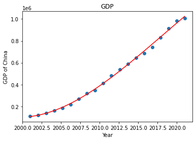

```python
plt.scatter(x,GDP)
plt.plot(x,regressor.predict(Poly_X),color='red')
plt.xlabel('Year')
plt.ylabel('GDP of China')
plt.title('GDP')
plt.show()
```

然后我们画图，这部分代码我们需要注意的是第二行，我们画拟合线时x都知道，但regressor.predict(Poly_X)的意思就是拿我们已经学习好，得到参数的regressor去predict（预测）Poly_X，也就是我们的预测的GDP值

你可以去改变degree去改变拟合的函数形式，注意，如果degree是1的话就是我们的线性回归，你可以去改变GDP与对应的x去用多项式回归你想要的数据